# Tutorial - Workshop R - BIOME

Felipe A. S. Barbosa

Setembro 29, 2021

# Workshop R - BIOME Lab

##### Olá pessoal, nesse script estão contidos os códigos e funções mais utilizadas para análises de dados de microrganismos. Qualquer dúvida, podem entrar em contato através do email felipe.as.barbosa99@gmail.com

### Etapa pré-workshop

Caso não tenham o R ou Rstudio instalado, recomendo que assistam esse [vídeo](https://youtu.be/l1bWvZMNMCM)

Não tem muita complicação. É basicamente baixar e instalar tanto o [R](https://vps.fmvz.usp.br/CRAN/) quanto o [Rstudio](https://www.rstudio.com/products/rstudio/download/#download). No ubuntu/linux talvez seja mais complicado, por conta das bibliotecas adicionais. Mas o vídeo explica tudo.

Uma vez que tenham baixado os dois, é importante baixar também os pacotes, que contém funções importantes para o desenvolvimento desse workshop.

Nele, serão usados os seguintes pacotes: dplyr, ggplot2, tidyverse, vegan, reshape, RColorBrewer e cowplot

Vocês podem instalar todos eles de uma vez, é só copiar e colar o comando no console do R

```r
install.packages(c("dplyr", "ggplot2", "tidyverse", "vegan", "reshape", "RColorBrewer" e "cowplot"), dependencies = TRUE)
```

Recomendo que instalem antes, e caso tenham algum problema, primeiro verifiquem se estão utilizando a versão mais recente dos programas, e se existe alguma atualização para o seu sistema. São pacotes muito utilizados e que recebem atualizações frequentes. Por isso, as vezes podem acontecer alguns problemas. Mas não se desespere. Podem entrar em contato caso não consigam resolver.

Em último caso, se não se sentirem confortáveis com a instalação dos programas ou pacotes, o R oferece uma [plataforma em nuvem](https://rstudio.cloud/). Nela, vocês tem maior liberdade para instalar os pacotes e rodar com mais “tranquilidade”. Mas tem o incoveniente de precisar fazer o upload dos arquivos de input e precisar da conexão com a internet o tempo todo. Use em caso de necessidade apenas.

#### Configurar área de trabalho:

Para definir onde o R vai procurar seus arquivos e escrever os seus outputs, precisamos designar um local (Working Directory ou “wd”). Caso não faça isso, sempre que for importar ou salvar um arquivo, ele vai fazer isso no /home,o que não é legal pra quem trabalha de forma organizada!

Então para fazer isso, basta rodar setwd(), modificando o caminho nos parênteses para a sua pasta

```r
setwd("~/Documentos/Felipe/Workshop-R/")
```

Dica: O “~” antes da barra, encurta o caminho da pasta. O R vai se limitar a buscar arquivos que estão no usuário atual da máquina que está usando.

Caso queira conferir em qual wd você está, basta rodar “getwd()”, e o caminho aparecerá no console

```r
getwd()
```

```
## [1] "/home/felipe/Documentos/Felipe/Workshop-R"
```

Depois de definir o local para os nossos arquivos, vamos enfim importá-los para o Rstudio

#### Carregar os dados:

O R suporta diversos tipos de inputs, em diversos formatos. O mais comum, e mais seguro, são matrizes no formato “.csv” (Comma Separated Values). Elas podem ser abertas no excel ou libreoffice, e além de serem mais leves, também armazenam melhor informações numéricas.

Para carregar os inputs, usamos a função “read.csv()”.

```r
input_dados <- read.csv("inputs/phyla_groundwater_annotated_matrix_2021-03-08.csv")
```

Os arquivos csv, por padrão, vem separados por vírgulas. Porém, através de magia poderosa não recomendada, algumas pessoas conseguem salvar um csv com o separador de células diferente. Nesses casos, use o argumento “sep=” com o separador usado. Exemplo:

```r
exemplo <- read.csv(nome-do-arquivo.csv, sep = "/t")
```

No caso acima, o arquivo estaria separado por tabulação. Outros exemplos são: ponto e vírgula (“;”) e espaço em branco ("")

Se os arquivos estiverem em outros formatos, você pode usar “read.table(nome-do-arquivo, sep =”“)”

Depois de importar os dados e designar para um objeto do R, de nome “input_dados”, podemos visualizar a tabela de várias formas: resumidamente, no console, com

```r
input_dados[1:5,1:5]
```

```
##     samples        category_order             level_3 Proteobacteria
## 1 DRR125227 Porous_Contaminated 1 Porous_Contaminated    0.866641725
## 2 DRR125228 Porous_Contaminated 2 Porous_Contaminated    0.003052436
## 3 DRR125229 Porous_Contaminated 3 Porous_Contaminated    0.044139038
## 4 DRR125230 Porous_Contaminated 4 Porous_Contaminated    0.094365876
## 5 DRR125231 Porous_Contaminated 5 Porous_Contaminated    0.292631209
##   Actinobacteria
## 1     0.02283222
## 2     0.93250608
## 3     0.86345989
## 4     0.85078377
## 5     0.54223488
```

Onde os valores nos colchetes indicam os intervalos de linhas e colunas que você quer mostrar; outra alternativa é com a função view:

```r
view(input_dados)
```

Ou simplesmente clicando sobre ela na janela “Environment” do seu Rstudio

Como podemos ver, nessa tabela temos informações taxonômicas de microrganismos. Mais especificamente, nesse workshop vamos trabalhar com os dados da comunidade microbiana de aquíferos.

Inicialmente, vamos conferir se os dados estão corretos.

O colega que confeccionou a tabela informou que os dados estão em abundância relativa. Ou seja, a soma de todas as abundâncias em uma amostra deve ser 1. Vamos conferir se essa informação está correta:

Primeiro, para facilitar, vamos usar uma função que seleciona os dados conforme uma condição. Essa função faz parte do pacote **dplyr**

Provavelmente você já tem instalado. Caso não, instale com

```r
install.packages("dplyr")
```

Depois de baixado, use **library()** para carregar o pacote

```r
library(dplyr)
```

Depois de carregar o pacote, vamos então usar a função **select_if()**

```r
data_num <-select_if((input_dados), is.numeric)
```

Com ela, agora temos um objeto *data_num* que corresponde apenas aos dados numéricos, de acordo com a condição que fornecemos (*is.numeric*)

Dica: outras condições podem ser fornecidas, como *is.factor* ou *is.vector*

Você pode conferir, com:

```r
data_num[1:5,1:5]
```

```
##   Proteobacteria Actinobacteria  Firmicutes  Chloroflexi Cyanobacteria
## 1    0.866641725     0.02283222 0.009433621 0.0113521477  0.0015126342
## 2    0.003052436     0.93250608 0.061065503 0.0002000282  0.0002443283
## 3    0.044139038     0.86345989 0.085530540 0.0003739607  0.0003869724
## 4    0.094365876     0.85078377 0.022012203 0.0008838422  0.0004561341
## 5    0.292631209     0.54223488 0.037057176 0.0032684559  0.0014694371
```

```r
rowSums(data_num)
```

```
##   [1] 1 1 1 1 1 1 1 1 1 1 1 1 1 1 1 1 1 1 1 1 1 1 1 1 1 1 1 1 1 1 1 1 1 1 1 1 1
##  [38] 1 1 1 1 1 1 1 1 1 1 1 1 1 1 1 1 1 1 1 1 1 1 1 1 1 1 1 1 1 1 1 1 1 1 1 1 1
##  [75] 1 1 1 1 1 1 1 1 1 1 1 1 1 1 1 1 1 1 1 1 1 1 1 1 1 1 1 1 1 1 1 1 1 1 1 1 1
## [112] 1 1 1 1
```

Agora que sabemos que a tabela está com os dados corretos, vamos então analisar as suas informações

Vamos começar com as informações de riqueza dos filos nos ambientes

Vamos aproveitar o conjunto de dados apenas numéricos, e calcular o total de filos encontrados em cada amostra

```r
N0 <- rowSums(data_num > 0)
```

Agora temos um objeto com o total de filos encontrados para cada amostra. Vamos então unir as informações das amostras com essa informação:

```r
tN0<-data.frame(input_dados$samples,input_dados$level_3,N0)
tN0[1:5,1:3]
```

```
##   input_dados.samples input_dados.level_3  N0
## 1           DRR125227 Porous_Contaminated 149
## 2           DRR125228 Porous_Contaminated 120
## 3           DRR125229 Porous_Contaminated 141
## 4           DRR125230 Porous_Contaminated 149
## 5           DRR125231 Porous_Contaminated 149
```

Percebeu que as colunas ficaram com os nomes que demos na linha onde juntamos as informações? Vamos corrigir, afinal, queremos um novo objeto com nomes claros nas suas colunas. Vamos utilziar a função **c** (combinar) para juntar os nomes que queremos dar as colunas

```r
colnames(tN0) <- c("Samples", "Category", "Richness")
colnames(tN0)
```

```
## [1] "Samples"  "Category" "Richness"
```

#### Primeiro gráfico - Boxplot

Agora, com essas informações, em tantas linhas, fica difícil observar qualquer padrão, correto? Sendo assim, que tal partirmos pro nosso primeiro gráfico?

Vamos utilizar um dos pacotes mais famosos do R, o **ggplot2**. Caso não tenha instalado, prossiga da mesma forma que instalou o pacote **dplyr** anteriormente, com o *install.packages*

```r
library(ggplot2)
```

Para a sua nossa sorte, os dados que temos até agora estão devidamente organizados para um gráfico desse tipo. Então vamos partir direto pra sua confecção.

O ggplot funciona como camadas, onde você pode adicionar novas camadas e mudar as configurações de cada uma delas.

Como exemplo, vamos tentar só adicionar os nossos dados na função ggplot e ver o resultado

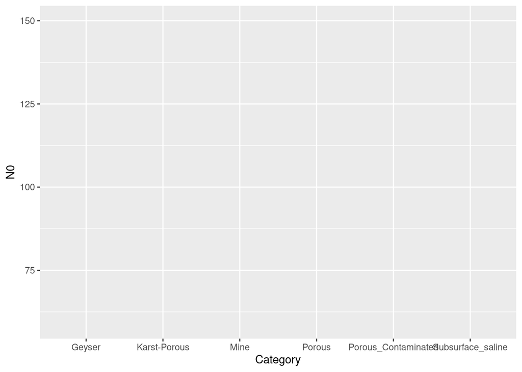

```r
p1 <- ggplot(tN0, aes(x = Category, y=N0))
p1
```

Vazio, né? Isso é por que não definimos qual o tipo de gráfico que vai ser colocado. Então ele só plota o quadro vazio da primeira camada, com as informações dos eixos, que fornecemos.

Vamos agora adicionar uma segunda camada, com o tipo de gráfico e a cor que queremos

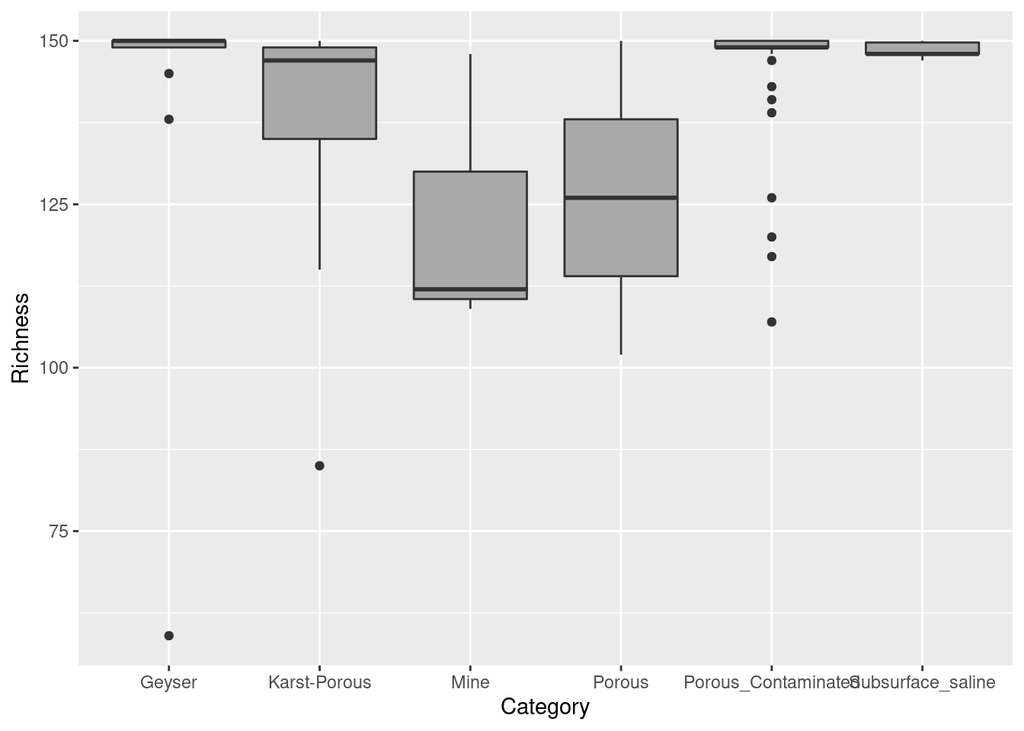

```r
p1 <- ggplot(tN0, aes(x = Category, y=Richness))+
  geom_boxplot(fill = "darkgray")
p1
```

Agora sim!

Mas vamos incrementar mais, afinal, queremos um gráfico muito bonito e digno de uma revista científica.

Vamos mudar o tema, para um fundo branco, com a camada **theme_bw()** e também vamos mudar o nome dos eixos, com o **labs**. Com o **theme**, podemos mudar vários elementos no gráfico, como o tamanho, estilo e cor da fonte dos eixos, remover a borda dos eixos e as linhas de dentro do gráfico. Pra ficar mais simples, vamos adicionar tudo isso de uma vez. Mas você pode (e eu recomendo) experimentar adicionar cada linha de uma vez.

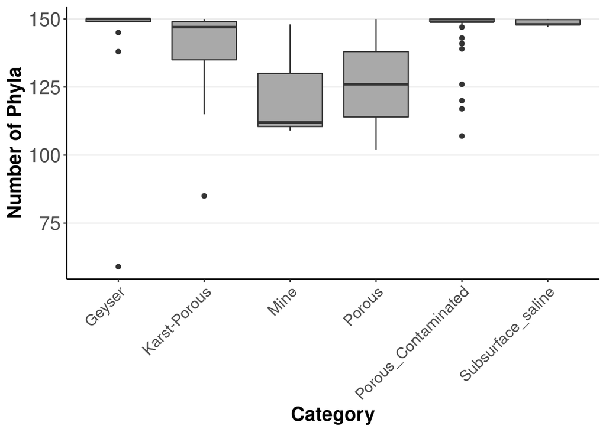

```r
p1 <- ggplot(tN0, aes(x = Category, y=N0))+
  geom_boxplot(fill = "darkgray")+
  guides(fill=NULL)+
  theme_bw()+
  labs(x = "Category", y = "Number of Phyla")+
  theme(axis.text.x = element_text(size=13, angle=45, hjust = 1, vjust=1))+
  theme(axis.title.x = element_text(size=16,face="bold"),
        axis.title.y = element_text(size=16,face="bold"))+
  theme(axis.text.y = element_text(size=16))+
  theme(panel.border = element_blank())+
  theme(panel.grid.major.x = element_blank())+
  theme(panel.grid.minor.y = element_blank())+
  theme(axis.line = element_line())
p1
```

O nível taxonômico de Filo é muito abrangente, então a maioria das amostras ficou no limite de 150, que é o total de filos que temos na nossa base de dados. Mas ainda assim, deu pra ver que a maioria das amostras de algumas categorias não tem todos os filos.

Agora que estamos orgulhosos do nosso primeiro gráfico desse tutorial, vamos salvar!

Antes, aqui vai uma dica: as vezes fazemos várias versões de uma mesma figura. Ou de uma tabela. Ou qualquer coisa que possa ser feita no R. E pra não se perder, qual a melhor forma do que colocar uma data da versão em que você produziu aquilo? Por isso, eu recomendo muito que sempre, em todos os seus códigos, vocês usem a seguinte linha:

```r
library(tidyverse)
d <- Sys.Date() %>% str_replace_all("-","_")
```

Ela utiliza alguns recursos importantes do **tidyverse**, que vamos usar mais lá na frente: a função *str_replace_all*, junto com um acessório importante do pacote **tidyverse**, o %>%, que indica que uma função deve ser usada em determinado objeto de uma determinada função. Aqui basicamente pegamos a data do sistema do seu computador, e substituímos os “-” por "_" e salvamos no objeto “d”

Depois disso, vamos então usar o *ggsave* para salvar a figura:

```r
ggsave(plot = p1, filename = paste("outputs/richness_boxplot", d, ".png", sep = ""))
```

Sempre que quiser salvar um plot agora, é só usar essa linha, mudando, claro, o nome do plot, e também o nome do arquivo.

#### nMDS - analisando as diferenças/similaridades entre as amostras (e sua categoria)

Agora, vamos analisar essa diversidade taxonômica com um pouquinho mais de detalhes. Vamos analisar o quão diferente as amostras são umas das outras. Pra isso, a melhor opção é o **nMDS** (nonMetric Multidimensional Scaling ou Análise de escalonamento multidimensional não métrico)

Vamos aproveitar os dados numéricos que temos para realizar o cálculo das diferenças do nMDS

Para esse cálculo, vamos utilizar um pacote tão famoso quanto o **ggplot2**, o **vegan**. Siga o mesmo processo de antes para carregar ele.

```r
library(vegan)
```

Agora, vamos então usar a função *metaMDS*

```r
ord <- metaMDS(data_num)
```

```
## *** No convergence -- monoMDS stopping criteria:
##     20: stress ratio > sratmax
```

Matematicamente, o nMDS calcula as distâncias entre os valores num espaço multidimensional, e então as converte para as duas dimensões que utilizamos. Nesse processo de conversão, existe o “stress”, que á a diferença entre a distância no espaço multidimensional e o espaço 2D. O ideal é tenhamos o menor stress possível na nossa análise.

Por padrão, essa função utiliza as matrizes de distância de Bray-Curtis, mas também aceita outros tipos, como:

```r
metaMDS(data_num, distance = "euclidean")
metaMDS(data_num, distance = "jaccard")
```

Observando o objeto criado com a função, não parece muita coisa, né?

```r
ord
```

```
##
## Call:
## metaMDS(comm = data_num)
##
## global Multidimensional Scaling using monoMDS
##
## Data:     data_num
## Distance: bray
##
## Dimensions: 2
## Stress:     0.1613148
## Stress type 1, weak ties
## No convergent solutions - best solution after 20 tries
## Scaling: centring, PC rotation, halfchange scaling
## Species: expanded scores based on 'data_num'
```

O nosso objeto “ord” tem todas as informações das distâncias entre as comunidades microbianas das amostras. Pra ficar mais prático, vamos logo plotar essas informações.

##### Preparando os dados

Bom, como vamos plotar as informações do objeto “ord” com as informações das amostras, se cada uma está num lugar diferente e com formatos diferentes?

Vamos unir as informações em um novo dataframe (matriz). Aqui, vamos usar uma função semelhante a **c** usada anteriormente. A função **cbind** une vetores, matrizes ou dataframes em um único objeto.

Para facilitar, vamos criar vetores com o nome das nossas amostras e com as categorias de cada uma

```r
samples <- input_dados$samples
category <- input_dados$level_3
```

Agora, então, unimos todas essas informações

```r
ord_df <- cbind(samples,category,data.frame(ord$points))
```

Perceba que também utilizamos a função **data.frame** dentro da função **cbind**. Isso por que precisamos transformar os dados dos pontos que serão plotados (points) do objeto “ord” em um dataframe antes de uní-los.

Vamos também mudar o nome das colunas, pra que o novo objeto também tenha informações claras.

```r
colnames(ord_df) <- c("Samples", "Category", "MDS1","MDS2")
```

Uma coisa que ajuda na hora de analisar algo ou confeccionar um script, é a função **attach**. Ela faz com que o dataframe fique no “caminho” do R. Assim, você só precisa dar o nome de uma coluna, e ele vai saber onde procurar. Não é obrigatório, mas ajuda a evitar erros.

```r
attach(ord_df)
```

Agora, enfim, vamos plotar o nosso nMDS. Dessa vez, vamos direto ao que queremos. Vamos colorir os pontos conforme as categorias, para conseguir ver melhor as diferenças não só entre as amostras, mas entre cada tipo de aquífero também.

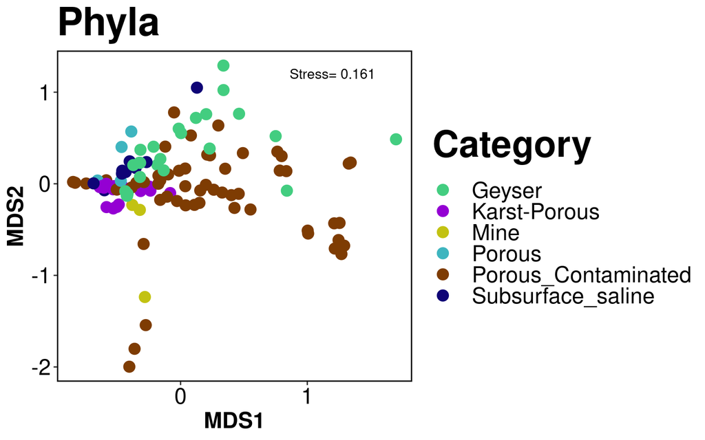

```r
plot_tax <- ggplot(ord_df, aes(x=MDS1, y=MDS2, color=Category)) +
  geom_point(size = 4) +
  theme_bw()+
  labs(title = "Phyla")+
  theme(plot.title = element_text(face = "bold", size = 32), plot.tag = element_text(face = "bold", size = 36))+
  theme(legend.position = "right", legend.title = element_text(size = 30, face = "bold"))+
  theme(panel.border = element_rect(colour = "black", size=1))+
  theme(legend.key=element_rect(fill='white'))+
  theme(legend.key = element_rect(colour = "white"))+
  scale_colour_manual(values=c("#43CD80","#9400D3","#c2c212", "#3eb5bf", "#7e3c03", "#0f0476"))+
  theme(legend.text=element_text(size=18))+
  theme(axis.title.x = element_text(face="bold", size=18))+
  theme(axis.title.y = element_text(face="bold", size=18))+
  theme(axis.text.x = element_text(size=18,color="black"))+
  theme(axis.text.y = element_text(size=18,color="black"))+
  theme(axis.line.x=element_blank())+
  theme(axis.line.y=element_blank())+
  annotate("text", x = 1.2, y = 1.2, label = paste("Stress=",round(ord$stress, digits=3)), size = 4)+
  theme(panel.grid.major.x = element_blank() ,
        panel.grid.minor.x = element_blank() ,
        panel.grid.major.y = element_blank(),
        panel.grid.minor.y = element_blank())

plot_tax
```

Pode observar que apareceram elementos novos no código do plot? Os mais significativos foram “scale_color_manual”, uma função em que você define manualmente o código das cores usadas no gráfico. E a “annotate”, que vai escrever o que você definir no local que você definir. Aqui, nós usamos a função *paste* pra colocar os dados do stress calculado no nosso metaMDS

Percebe que as legendas estão com um "_" entre as palavras? Pode parecer algo simples. Mas agora vamos aprender como substituir algum caractere nas nossas matrizes de forma automática.

Pra isso, vamos usar novamente a função *str_replace_all* do pacote **tidyverse**. Aqui, a função *mutate*, do **dplyr** vai criar uma variável nova a partir da antiga “Category”, porém com as mudanças dadas na função *str_replace_all*

```r
ord_df <- ord_df %>% mutate(Category = str_replace_all(Category, "Porous_Contaminated", "Porous Contaminated") %>% str_replace_all("Subsurface_saline", "Subsurface Saline"))
```

Para conferir, vamos fazer uma conversão da nossa variável “Category” em fator, e ver quais os seus “levels”

```r
levels(as.factor(ord_df$Category))
```

```
## [1] "Geyser"              "Karst-Porous"        "Mine"
## [4] "Porous"              "Porous Contaminated" "Subsurface Saline"
```

Agora sim, com os nomes novos, vamos salvar de novo a informação das categorias

```r
category <- ord_df$Category
```

E então vamos rodar o gráfico novamente

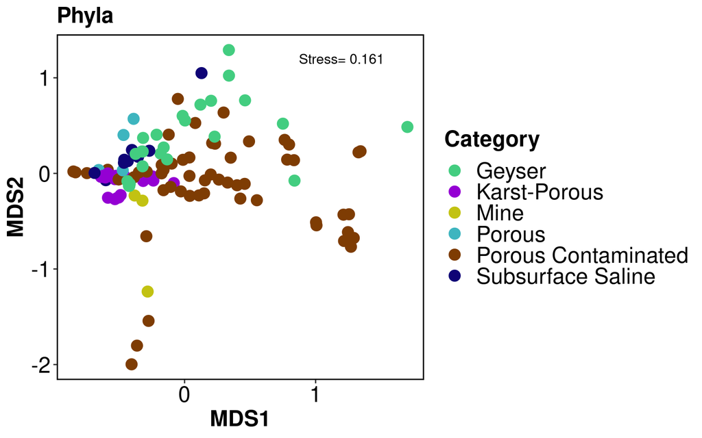

```r
plot_tax <- ggplot(ord_df, aes(x=MDS1, y=MDS2, color=Category)) +
  geom_point(size = 4) +
  theme_bw()+
  labs(title = "Phyla")+
  theme(plot.title = element_text(face = "bold", size = 18))+
  theme(legend.position = "right", legend.title = element_text(size = 18, face = "bold"))+
  theme(panel.border = element_rect(colour = "black", size=1))+
  theme(legend.key=element_rect(fill='white'))+
  theme(legend.key = element_rect(colour = "white"))+
  scale_colour_manual(values=c("#43CD80","#9400D3","#c2c212", "#3eb5bf", "#7e3c03", "#0f0476"))+
  theme(legend.text=element_text(size=18))+
  theme(axis.title.x = element_text(face="bold", size=18))+
  theme(axis.title.y = element_text(face="bold", size=18))+
  theme(axis.text.x = element_text(size=18,color="black"))+
  theme(axis.text.y = element_text(size=18,color="black"))+
  theme(axis.line.x=element_blank())+
  theme(axis.line.y=element_blank())+
  annotate("text", x = 1.2, y = 1.2, label = paste("Stress=",round(ord$stress, digits=3)), size = 4)+
  theme(panel.grid.major.x = element_blank() ,
        panel.grid.minor.x = element_blank() ,
        panel.grid.major.y = element_blank(),
        panel.grid.minor.y = element_blank())

plot_tax
```

Cada ponto em um gráfico nMDS representa a comunidade microbiana total dessa amostra. Os símbolos mais próximos têm microbiotas mais semelhantes, enquanto os mais distantes têm menos semelhantes.

Esse nMDS não mostrou muita diferença entre as categorias. Apesar de analisar todas essas distâncias e diferenças entre as comunidades, o nMDS não analisa nada estatisticamente. Então, pra tornar nossa análise mais robusta, que tal rodarmos alguma análise estatística pra incluir?

Como o foco agora é avaliar as diferenças entre tipos de aquíferos, precisamos antes saber como estão distribuídos os nossos dados, então, vamos ver quantas amostras cada tipo de aquífero tem. Vamos usar a função table, que vai contar a frequência dos valores que damos através de um fator.

```r
table(factor(category))
```

```
##
##              Geyser        Karst-Porous                Mine              Porous
##                  24                  17                   3                   4
## Porous Contaminated   Subsurface Saline
##                  57                  10
```

Podemos ver que os dados não estão nem um pouco balanceados. Por isso, o ideal é que usemos o ANOSIM (Analysis of Similarity). Esse teste não assume variâncias de grupo iguais, o que pode melhor explicar os nossos dados.

A função que usamos é a *anosim*, que está inclusa no pacote **vegan**

Enfim, vamos a análise:

```r
danosim <- anosim(data_num,category)
danosim
```

```
##
## Call:
## anosim(x = data_num, grouping = category)
## Dissimilarity: bray
##
## ANOSIM statistic R: -0.0005611
##       Significance: 0.48
##
## Permutation: free
## Number of permutations: 999
```

Esse teste nos dá o valor de R² e de p. Temos um pvalor MUITO alto, que mostra que a probabilidade da hipótese nula (não há diferença entre grupos) ser verdadeira é bem alta. O nosso R² próximo a zero também indica uma baixa dissimilaridade entre os tipos de aquífero. O valor negativo indica que a dissimilaridade é maior em um mesmo tipo de aquífero do que entre eles.

Mas e agora, como colocar isso no gráfico?

Lembra que eu comentei sobre a função *annotate* e que usamos ela para incluir o valor de stress no plot? Vamos usar ela novamente, dessa vez para adicionar os valores de R² e de p.

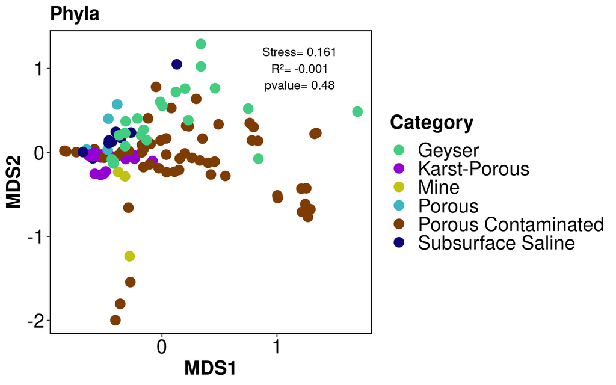

```r
plot_tax <- ggplot(ord_df, aes(x=MDS1, y=MDS2, color=Category)) +
  geom_point(size = 4) +
  theme_bw()+
  labs(title = "Phyla")+
  theme(plot.title = element_text(face = "bold", size = 18))+
  theme(legend.position = "right", legend.title = element_text(size = 18, face = "bold"))+
  theme(panel.border = element_rect(colour = "black", size=1))+
  theme(legend.key=element_rect(fill='white'))+
  theme(legend.key = element_rect(colour = "white"))+
  scale_colour_manual(values=c("#43CD80","#9400D3","#c2c212", "#3eb5bf", "#7e3c03", "#0f0476"))+
  theme(legend.text=element_text(size=18))+
  theme(axis.title.x = element_text(face="bold", size=18))+
  theme(axis.title.y = element_text(face="bold", size=18))+
  theme(axis.text.x = element_text(size=18,color="black"))+
  theme(axis.text.y = element_text(size=18,color="black"))+
  theme(axis.line.x=element_blank())+
  theme(axis.line.y=element_blank())+
  annotate("text", x = 1.2, y = 1.2, label = paste("Stress=",round(ord$stress, digits=3)), size = 4)+
  annotate("text", x=1.2, y=1, label = paste("R²=",round(danosim$statistic, digits = 3)), size = 4)+
  annotate("text", x=1.2, y=0.8, label = paste("pvalue=",round(danosim$signif, digits = 4)), size = 4)+
  theme(panel.grid.major.x = element_blank() ,
        panel.grid.minor.x = element_blank() ,
        panel.grid.major.y = element_blank(),
        panel.grid.minor.y = element_blank())

plot_tax
```

Agora sim, temos a análise visual das distâncias e também as análises estatísticas para as distâncias entre as comunidades microbianas, todas em um único plot, facilitando a visualização e entendimento da informação a ser passada.

#### Stackedbar

Analisamos as diferenças entre os tipos de aquíferos, mas em nenhum momento vimos quem são essas bactérias. Que tal um gráfico pra conseguir visualizar os grupos presentes em cada amostra, e as suas abundâncias?

Mas como vimos no gráfico da riqueza, temos 150 filos. Como visualizar isso de uma forma que não deixe o gráfico poluído? Uma boa ideia é aproveitar o conceito de “microbiota rara”, que corresponde aos grupos (nesse caso, Filos) que representam menos de 1% de toda a comunidade.

Pra isso, vamos agrupar todos esses grupos com abundância menor que 1%, e iremos chamá-los de “others”

Mais uma vez, vamos aproveitar o dataframe que contém apenas os valores numéricos das abundâncias.

O comando a seguir vai usar as funções *gather*, *group_by* e *summarise* para unir todos os filos com mais de 1% de abundância, filtrados com a função *filter*, com a condição dada (no nosso caso, > 1/100 = > 1%)

```r
abundants <- data_num %>% gather() %>% group_by(key) %>%
  summarise(taxa_mean = mean(value)) %>%
  filter(taxa_mean > 1/100) %>% pull(key)
abundants
```

```
##  [1] "Actinobacteria"           "Bacteroidetes"
##  [3] "candidate.division.WWE3"  "Candidatus.Moranbacteria"
##  [5] "Candidatus.Omnitrophica"  "Candidatus.Woesebacteria"
##  [7] "Chloroflexi"              "Elusimicrobia"
##  [9] "Euryarchaeota"            "Firmicutes"
## [11] "Planctomycetes"           "Proteobacteria"
## [13] "Spirochaetes"
```

Você pode se perguntar por que demos a condição para selecionar os filos com mais de 1% de abundância. E a explicação é que temos aqui apenas 13 Filos com uma abundância maior que a condição. Isso significa que o R precisou trabalhar menos para encontrar e colocar esses nomes juntos em um vetor. A partir dele, conseguimos selecionar um dataframe apenas com abundantes e outro apenas com microbiota rara, ou “others”

Vamos usar a função *select* do dplyr. Aqui, precisamos identificar qual o pacote da função, uma vez que o R base já possui uma função de mesmo nome. Essa função vai selecionar, na matriz numérica com todos os filos, apenas as colunas dos filos com o o nome presentes em “abundants”

```r
abundant.class <- dplyr::select(data_num, abundants)
```

Agora, vamos criar o dataframe dos “others”

```r
others <- dplyr::select(data_num, -abundants)
```

Com isso, podemos agora unir todos os valores de “others” em uma única coluna, com essa nova identificação, e então eles se tornam um grupo “único”. Vamos usar a função *rowSums* pra isso, e colocar o seu resultado em uma nova coluna chamada “Others” dentro do dataframe “abundants”

```r
abundant.class$Others <- rowSums(others)
```

Agora que temos um dataframe com os dados de todos os grupos (microbiota rara e abundantes), podemos unir com as informações das amostras e suas respectivas categorias

```r
abundant.class$category <- category
abundant.class$samples <- samples
```

Agora, para o tipo de gráfico que vamos fazer, precisamos usar a função *melt*. Ela irá unir todas as informações em colunas. Assim, cada linha terá um valor único. Essa função está presente no pacote **reshape**

```r
library(reshape)
final_df_stack <- melt(abundant.class)
```

Com essa tabela, o ggplot pode agora reconhecer os dados para formar o gráfico conforme o nosso objetivo

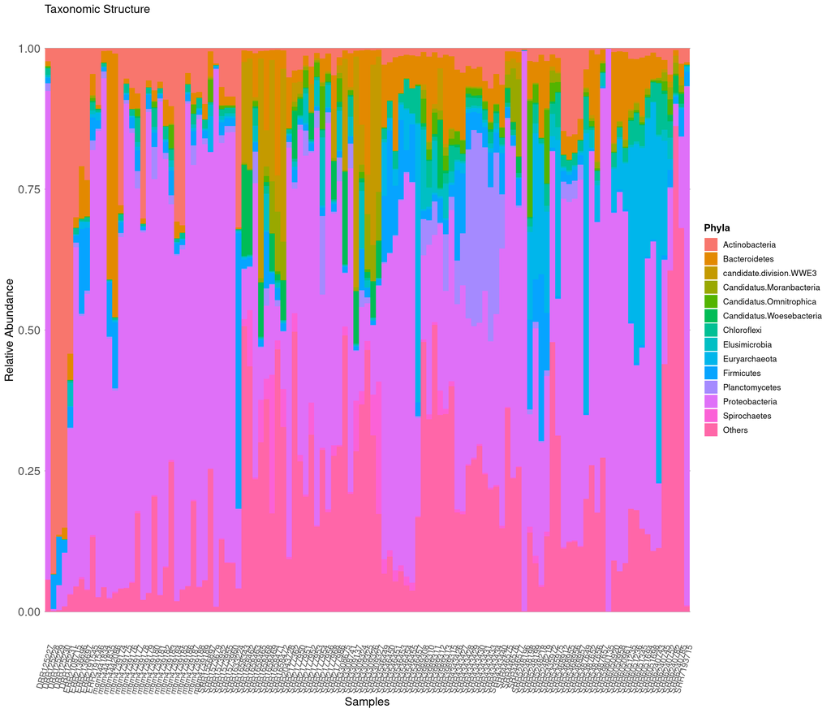

```r
tax_stack <- ggplot(final_df_stack, aes(x=samples, y=value, fill = variable)) +
  geom_bar(stat="identity",width=1)+
  labs(title = "Taxonomic Structure", x = "Samples", y = "Relative Abundance", fill = "Phyla")+
  guides(fill=guide_legend(reverse=FALSE))+
  scale_color_discrete(name = "Phyla")+
  #facet_grid(cols = vars(category), space = "free", scales = "free")+
  theme_bw() +
  theme(axis.text.x = element_text(angle = 75, hjust = 1, size = 10))+
  theme(axis.text.y = element_text(size=14))+
  theme(axis.title.x = element_text(size=14), axis.title.y = element_text(size=14), plot.title = element_text(size = 14))+
  theme(axis.line = element_line())+
  theme(axis.ticks = element_blank())+
  theme(panel.border = element_blank())+
  theme(panel.grid.major.x = element_blank(),
        panel.grid.major.y = element_line( size=.5, color="darkgrey"),
        panel.grid.minor.y = element_blank())+
  theme(axis.line.x=element_blank())+
  theme(axis.line.y=element_blank())+
  theme(axis.line.y=element_blank())+
  theme(legend.title=element_text(size=12, face = "bold"))+
  theme(legend.text=element_text(size=10))+
  theme(legend.justification=c(0.5,0.5), legend.position=c("right"))
tax_stack
```

As cores ficaram horríveis, não é? O que acontece é que as cores manuais do R sempre vão tentar esse “degradê” entre as cores, o que não fica legal pra alguns gráficos. Por isso, temos algumas alternativas

A primeira delas, é dar o código de cada uma manualmente. Isso fica complicado quando vc precisa de mais do que 10 cores. Então vamos descartar ela nesse momento.

A segunda, é com o pacote **RColorBrewer**. Esse pacote tem várias paletas de cores, que podem ser escolhidas para preencher os seus gráficos. Usamos ele com a função *scale_fill_brewer*, e então indicamos a paleta escolhida. No nosso caso, Temos um pequeno problema. Precisamos de 14 cores, e o máximo que uma paleta tem, é 12. Então, precisamos juntar mais de uma paleta. Faremos assim:

As paletas são divididas em categorias de cores divergentes (div), cores sequenciais (seq) e qualitativas (qual).

```r
library(RColorBrewer)
qual_col_pals = brewer.pal.info[brewer.pal.info$category == 'div',]
col_vector = unlist(mapply(brewer.pal, qual_col_pals$maxcolors, rownames(qual_col_pals)))
```

Então, podemos agora selecionar as nossas cores. E vamos também fazer uma pré-visualização delas

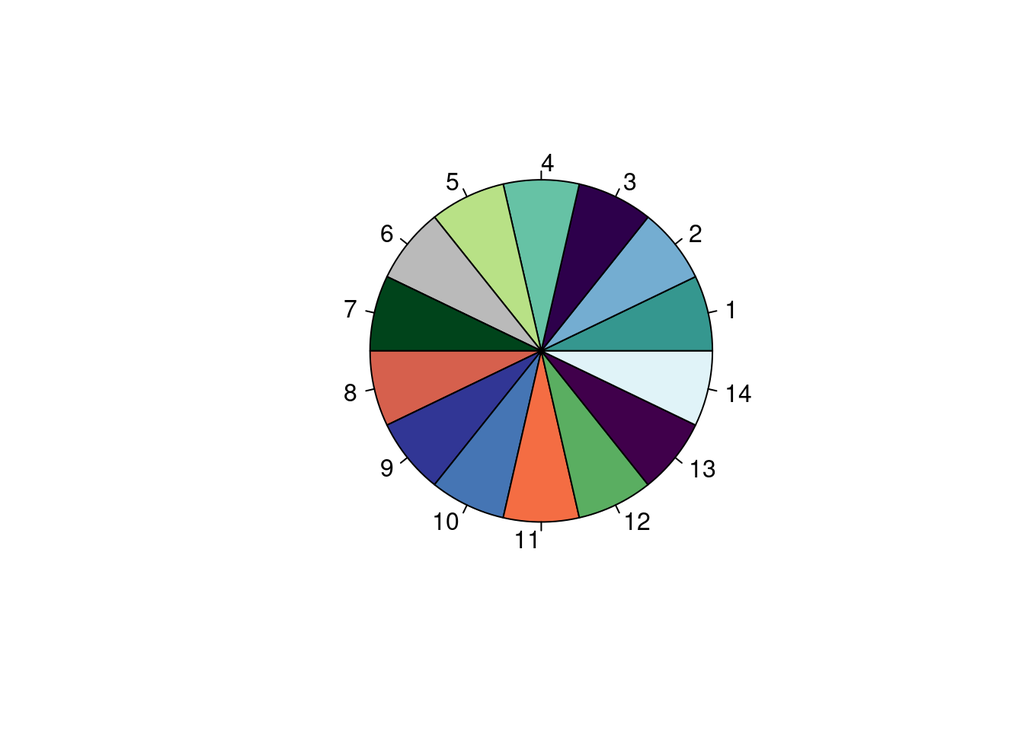

```r
# "14" é o número de cores que você precisa do seu gráfico
colors=col_vector[sample(1:length(col_vector),14)]
pie(rep(1,14), col=sample(col_vector, 14))
```

Ah, uma dica é salvar o objeto “colors”, já que toda vez que você rodar o código, novas cores vão aparecer. Salve com:

```r
colors <- data.frame(colors)
write.csv(colors, file = paste("outputs/colors_to_plots",d,".csv", sep = ","), row.names = F)
```

Lembrando de sempre colocar a data no nome do arquivo!

Se quiser reutilizar essas cores, carregue o arquivo novamente, com:

```r
colors_saved <- read.csv("outputs/colors_to_plots.csv", sep = ",")
#E então nomeie com o mesmo nome anterior
colors <- colors_saved$colors
```

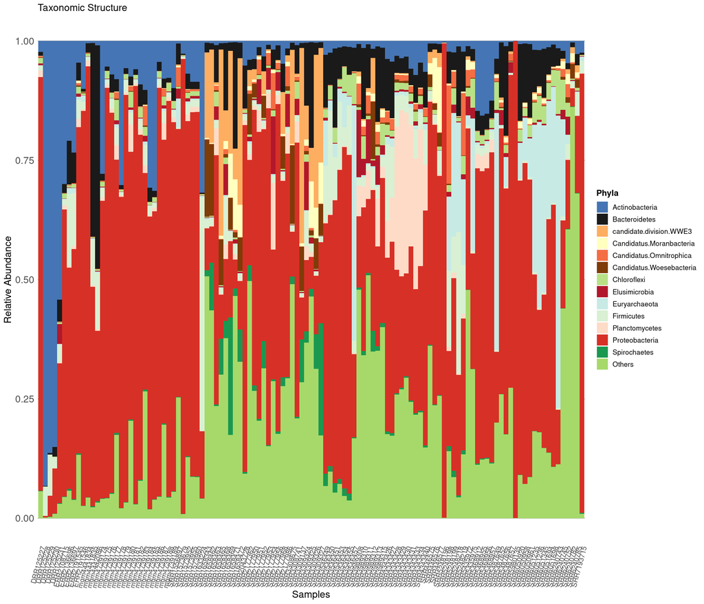

```r
tax_stack <- ggplot(final_df_stack, aes(x=samples, y=value, fill = variable)) +
  geom_bar(stat="identity",width=1)+
  labs(title = "Taxonomic Structure", x = "Samples", y = "Relative Abundance", fill = "Phyla")+
  guides(fill=guide_legend(reverse=FALSE))+
  #scale_color_discrete(name = "Phyla")+
  #facet_grid(cols = vars(category), space = "free", scales = "free")+
  scale_fill_manual(values = colors)+
  theme_bw() +
  theme(axis.text.x = element_text(angle = 75, hjust = 1, size = 10))+
  theme(axis.text.y = element_text(size=14))+
  theme(axis.title.x = element_text(size=14), axis.title.y = element_text(size=14), plot.title = element_text(size = 14))+
  theme(axis.line = element_line())+
  theme(axis.ticks = element_blank())+
  theme(panel.border = element_blank())+
  theme(panel.grid.major.x = element_blank(),
        panel.grid.major.y = element_line( size=.5, color="darkgrey"),
        panel.grid.minor.y = element_blank())+
  theme(axis.line.x=element_blank())+
  theme(axis.line.y=element_blank())+
  theme(axis.line.y=element_blank())+
  theme(legend.title=element_text(size=12, face = "bold"))+
  theme(legend.text=element_text(size=10))+
  theme(legend.justification=c(0.5,0.5), legend.position=c("right"))
tax_stack
```

Como temos muitas colunas, as coisas podem parecer meio bagunçadas. Então vamos tentar agrupar as amostras por tipo de aquífero, e separar elas no gráfico com o *facet_grid*

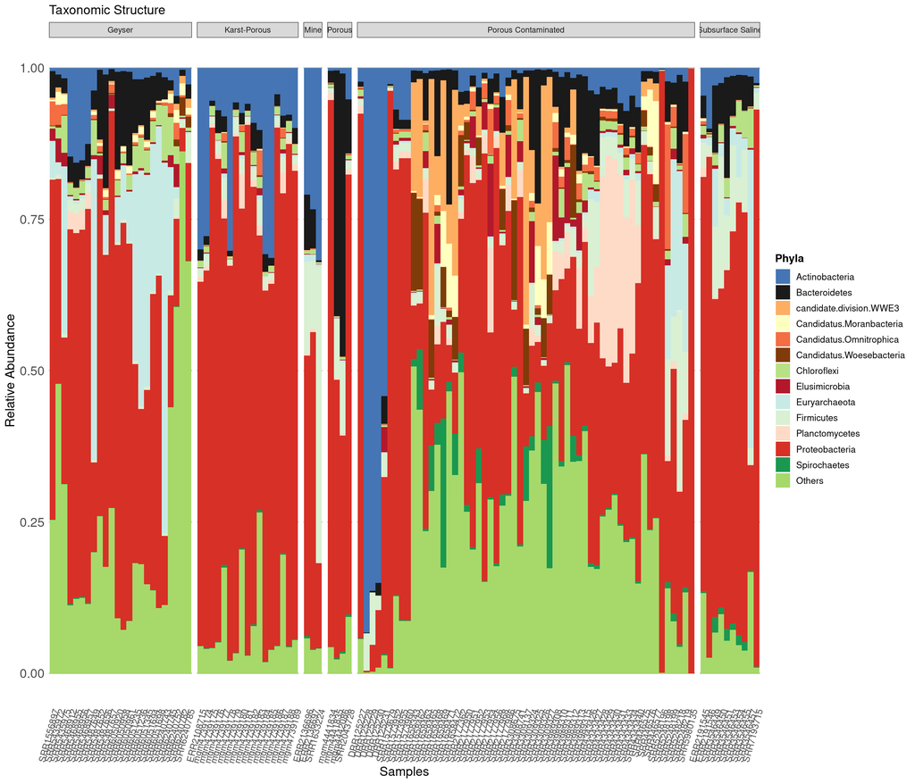

```r
tax_stack <- ggplot(final_df_stack, aes(x=samples, y=value, fill = variable)) +
  geom_bar(stat="identity",width=1)+
  labs(title = "Taxonomic Structure", x = "Samples", y = "Relative Abundance", fill = "Phyla")+
  guides(fill=guide_legend(reverse=FALSE))+
  facet_grid(cols = vars(category), space = "free", scales = "free")+
  scale_fill_manual(values = colors)+
  theme_bw() +
  theme(axis.text.x = element_text(angle = 75, hjust = 1, size = 10))+
  theme(axis.text.y = element_text(size=14))+
  theme(axis.title.x = element_text(size=14), axis.title.y = element_text(size=14), plot.title = element_text(size = 14))+
  theme(axis.line = element_line())+
  theme(axis.ticks = element_blank())+
  theme(panel.border = element_blank())+
  theme(panel.grid.major.x = element_blank(),
        panel.grid.major.y = element_line( size=.5, color="darkgrey"),
        panel.grid.minor.y = element_blank())+
  theme(axis.line.x=element_blank())+
  theme(axis.line.y=element_blank())+
  theme(axis.line.y=element_blank())+
  theme(legend.title=element_text(size=12, face = "bold"))+
  theme(legend.text=element_text(size=10))+
  theme(legend.justification=c(0.5,0.5), legend.position=c("right"))
tax_stack
```

Ainda assim, falta algo. Que tal se organizarmos os dados para que os grupos apareçam com as abundâncias em ordem crescente/decrescente?